# Problem Set #2 - Richardson

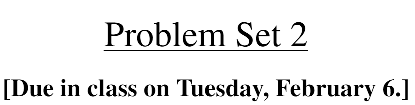

## Question 1

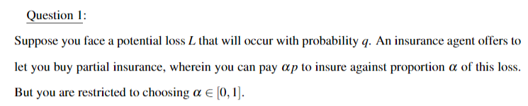

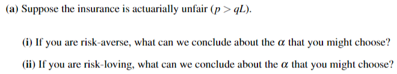

(a) In this situation, a risk-neutral individual will not buy insurance as it reduces their expected value

Example: L = 100, q = 0.02, p = 3. Zero insurance is (0,.98;100,.02) and full insurance is (3,1)

- (i) A risk-averse individual may purchase a varying amount of insurance, depending on their degree of risk-aversion
- (ii) A risk-loving individual will not purchase insurance since they wouldn't purchase it for actuarially fair, let alone actuarially unfair.

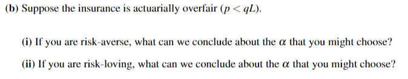

(b) In this situation, purchasing more insurance will increase expected value, and a risk-neutral individual will buy as much as possible.

- (i) A risk-averse individual will capitalize on the insurance and buy the maximum amount
- (ii) A risk-loving individual will buy a varying amount of insurance, with the most risk loving choosing $\alpha=0$, as it offers them a chance at paying nothing.

## Question 2

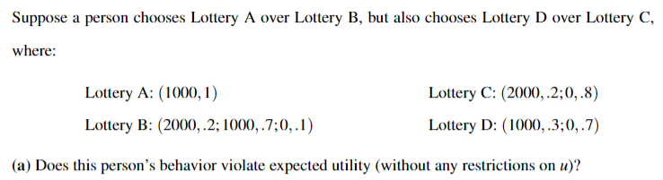

(a) To choose these option, Eu(A)>Eu(B), and Eu(D)>Eu(C),

This implies $$u(1000)>u(2000)*.2+u(1000)*.7 \\ u(1000)*.3>u(2000)*.2$$ Both of these evolve to the same implication $$u(1000)-u(1000)*0.7>u(2000)*.2 \implies u(1000) > u(2000)*.66 \\ u(1000)*.3*3.3>u(2000)*.2*3.3 \implies u(1000) > u(2000)*.66 $$

As such, this is internally consistent and does not violate expected utility

(b) This does not violate more is better, as the individual may value a certain reward over an uncertain reward. The utility function must be downward sloping and devalue 2000 reward to the point that 2/3rds of u(2000) is less than u(1000)

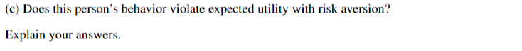

(c) In order to prefer u(1000) to u(2000)*.66, u(2000) must be at most 3/2 u(1000), while being risk-neutral requires u(2000) to be 4/2 u(1000) and risk-loving to be greater than that. Thus this person appears to be risk-averse

## Question 3

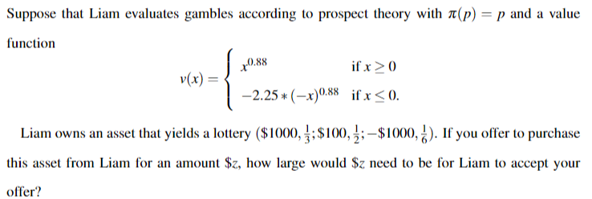

Lets call the lottery in question A. $V(A)=1000^{.88}*.33+100^{.88}*.5-2.25*(1000)^{.88}*.17=5.85$

Liam would sell the lottery for any value z such that $z^{.88}\geq5.85 \implies \$z\geq\$7.44$

## Question 4

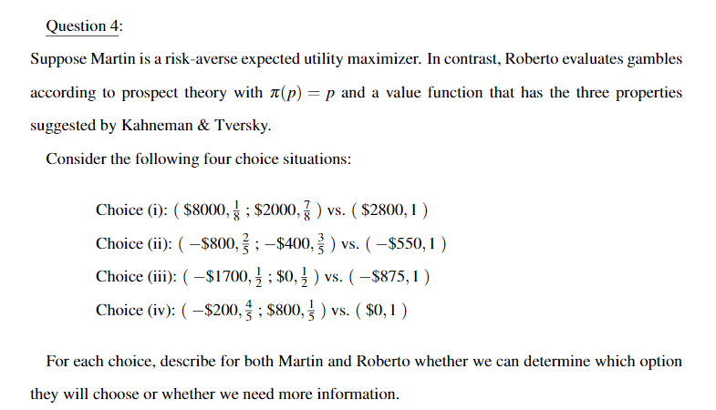

The three properties are

- The carriers of value are changes in wealth -> jeff bezos still likes winning
- Loss aversion: People dislike losses more than they like same-sized gains.
- Diminishing Sensitivity: People pay less attention to incremental differences when changes are further away from the reference point

Choice (i):  
Martin will choose either option, with option B chosen for high risk aversion and option A chosen for lower risk aversion.  
Since Roberto evaluates probabilites properly $(\pi(p)=p)$, he will likely be risk-averse in a bet of all gains will undervalue the $8000 reward and lean towards option B

Choice (ii):  
Martin is risk-averse and will not want to risk getting the -$800 bill, so he will choose option B. A risk-neutral person would also choose this option due to the expected value being higher <br> Roberto is extra-sensitive to losses and will become risk-loving if it gives him the opportuntiy to get the lowest loss of -$400, even at the risk of getting -$800

Choice (iii):  
Martin is risk averse, and will choose option B  
Roberto is risk loving in a game of all losses, and will choose option A

Choice (iv):  
Martin is risk averse and will choose option B, even though they have the same expected value his utility function will push down the value of $800, resulting in option B having higher expected utility  
Roberto appreciates the probabilites of all outcomes properly, so his value function will push the value of each outcome away from the pure expected value model. Since Losses hurt more than gains, Roberto will devalue option A and choose option B.

## Question 5

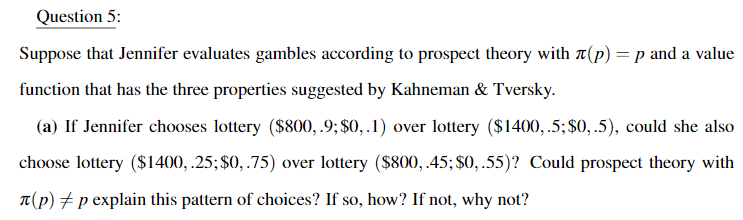

(a) The prospect theory value function is still a function, so for $\pi(p)=p$ the two descisions should be able to be transformed to have the same conclusion. $$ \begin{cases} v(800)*0.9>v(1400).5 \implies v(800)>v(1400).556\\ v(1400)*.25>v(800).45 \implies v(1400).556>v(800) \end{cases} $$ However both options cannot be greater than eachother ($(1400).556\ngtr (1400).556$), so this statement contradics itself and doesn't agree with prospect theory. With $\pi(p) \neq p$ this is possible, as it could overrate the likelyhood of a 90% chance to occur and overvalue a 25% chance, resulting in both statements being possible.

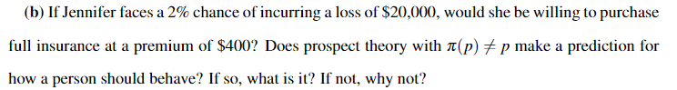

(b) $20,000*.02=400$. A risk neutral individual would go either way on this choice.

Prospect theory with $\pi(p)\neq p$ could cause someone to reduce a 2% chance to near zero, resulting in the negative outcome being ignored and the risky lottery being chosen instead of the insurance. This also aligns with the idea that individuals are more risk-loving in a situation of all losses, where an individual will take a risk to avoid all losses (-$400 and -$20000)

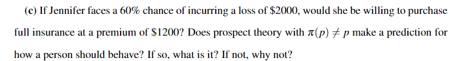

(c) $2000*.6 = 1200$ again, a risk neutral individual will go either way

While people tend to appreciate probabilities more accurately with medium probabilites in prospect theory, prospect theory still suggests that an individual will be risk-loving due to their insensitivity to large losses compared to smaller ones, and Jennifer will likely choose to skip on insurance still to try to get the optimal $0 loss

## Question 6

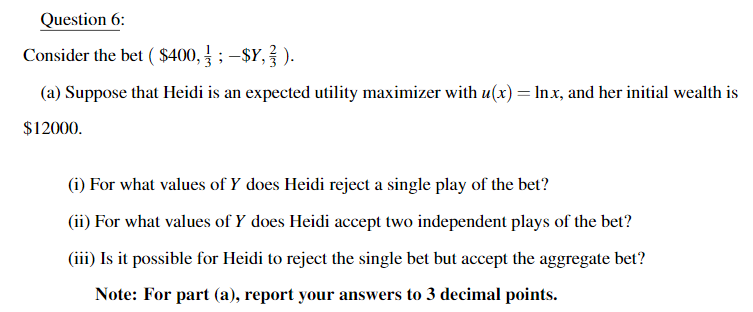

(a) Remember that expected utility includes current wealth u(w+x)

- (i) $EU(\text{bet})= \frac{1}{3}u(12000+400)-\frac{2}{3}u(12000-Y)$. Lets evaluate this when expected utility of the the bet is even with the utility of Heidi's current situation $(\$12000,1)$. $$ \frac{\ln(12400)}{3}+\frac{2\ln(12000-Y)}{3}=\ln(12000) \\ Y = -12000 \sqrt{30/31} + 12000 = 195.135 $$ Any value greater than 195 causes Heidi to reject the bet, which makes sense since u(x)=ln(x) is a risk-averse function, while risk-neutral would accept at $Y=200$
- (ii) $\text{bet}^2= (800,\frac{1}{9};400-Y,\frac{4}{9};-2Y,\frac{4}{9})$. Again, lets compare with the lottery of doing nothing $(\$12000,1)$ $$ 1/9*\ln(12800)+4/9*\ln(12400-Y)+4/9*\ln(12000-2Y)=\ln(12000) \\ Y = -400 \left(\sqrt{64 + 225 \sqrt[4]{15}} - 23\right) = 195.133 $$ Which explains why you asked for 3 decimal points. Heidi accepts two plays for values of $Y$ less than $195.133$
- (iii) Rejection of single bet -> $Y>195.135$. Accept aggregate bet -> $Y<195.133$ There's no overlap, so this is not possible.

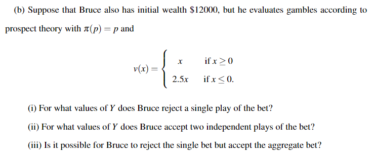

(b) Now we can neglect initial wealth thanks to the first principle from Amos and Daniel that I mentioned. In this case the alternative situation $V(\text{do nothing})=0$

- (i) $V(\text{bet})=1/3*v(400)+2/3*v(-Y)$ $$ 400 -2.5Y = 0 \\ Y = 400/2.5 = 160 $$ Bruce rejects for Y>160
- (ii) $V(\text{bet}^2)=1/9*v(800)+4/9v(400-Y)+4/9*v(-2Y)$. I'll assume v(400-Y) is positive based on the context $$ 1/9*800+4/9(400-Y)+4/9*2.5*-2Y=0 \\ Y = 100 $$ Bruce accepts two independent plays for Y<100
- (iii) Again, Y is greater than 160 to reject a single play, but it must be less than 100 to accept two, so it isn't possible

## Question 7

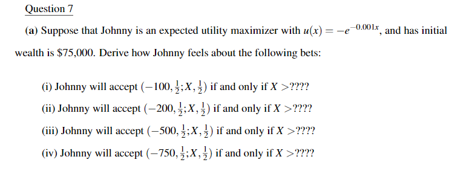

(a) Hey I remember this one. Remember to calcualte u(w+x) for evaluating lotteries

```python
# This'll whip the math out quick
import numpy as np

bets = np.array([-100,-200,-500,-750])
w = 75000

# u(bet+w) *.5 + u(X+w) *.5 = u(w)
# X = u^-1 (2u(w)-u(bet+w)) - w

def u(x):
    return -np.exp(-0.001*x)

def uinv(x):
    return -1000 * np.log(-1*x)

x = uinv(2*u(w)-u(bets+w)) + w
for i in range(len(x)):
    print(f'Johnny will accept bet #{i+1} if X is greater than {x[i]:.3f}')
# oh shit
```

```
Johnny will accept bet #1 if X is greater than 150111.123
Johnny will accept bet #2 if X is greater than 150250.261
Johnny will accept bet #3 if X is greater than 151046.175
Johnny will accept bet #4 if X is greater than nan
```

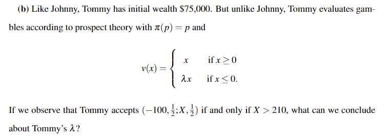

(b) Tommy must have a value $\lambda$ such that $$ -100*\lambda + 210 = 2*0 \\ \lambda = \frac{-210}{-100}=2.1 $$

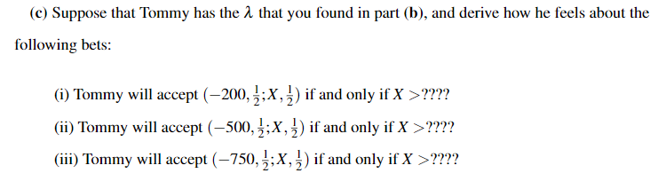

In each case $X$ will be -2.1 times each negative value  
(i) X>420  
(ii) X>1050  
(iii) X>1575

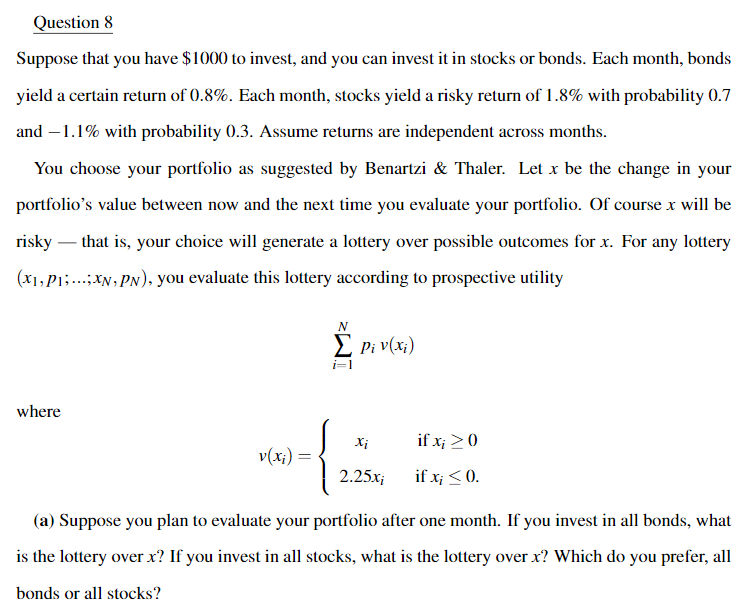

(a) For all invested in one lottery for a month, we can simply evaluate based on the monthly risky and certain yields. Remember, prospective theory is focused on changes

- All in bonds: $(1000*.008,1)$
- All in stocks: $(1000*.018,.7;1000*-.011,0.3)$

The prospective uitility of each is

- Bonds: $u(8)=8$
- Stocks: $0.7*u(18)+0.3*u(-11)=.7*18+.3*2.25*-11=12.6-7.425=5.175 $

I prefer all bonds

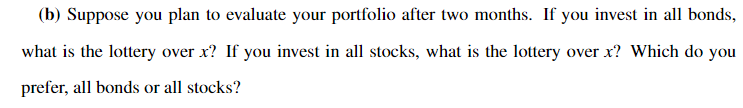

(b) This is similar to question #6

- $\text{bonds}^2$ $(1000*1.008^2-1000,1)$
- $\text{stocks}^2$ $(1000*1.018^2-1000,0.7^2;1000*1.018*.989-1000,0.7*0.3*2;1000*.989^2-1000,0.3^2) $

The prospective utility of each is

- $U(\text{bonds}^2)=16.064$
- $U(\text{stocks}^2)=.49*u(36.324)+.42*u(6.802)+0.09*u(-21.879)= .49*36.324+.42*6.802+.09*2.25*-21.879=16.225$

In this scenario, I'd prefer all stocks

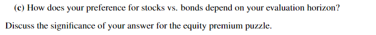

(c) It appears that further time evaluation leads to the low chance of losses being squished by the greatly increased interest (/ classical expected value). Perhaps the equity premium puzzle comes from the inability to understand how the uncertain lottery of stocks is actually more certain as time advances. and random chances compound. which isn't observed at a short-term view.

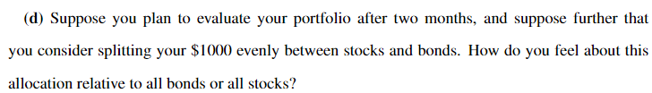

(d) Without calculating, I'm guessing this is inferior to simply investing entirely in stocks. If we replace every $1000 with $500 in part (b), it will simply scale down each item by half, including the resulting utilites, and the sum of utilities would be the average between the two, which is less.

## Question 9

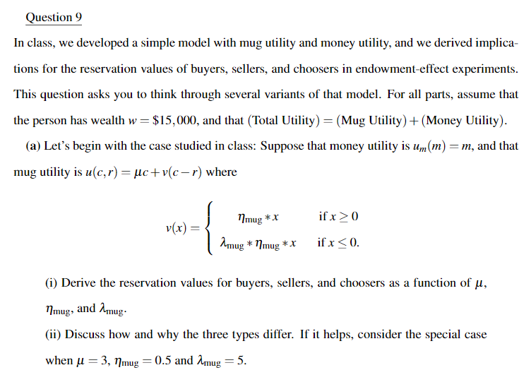

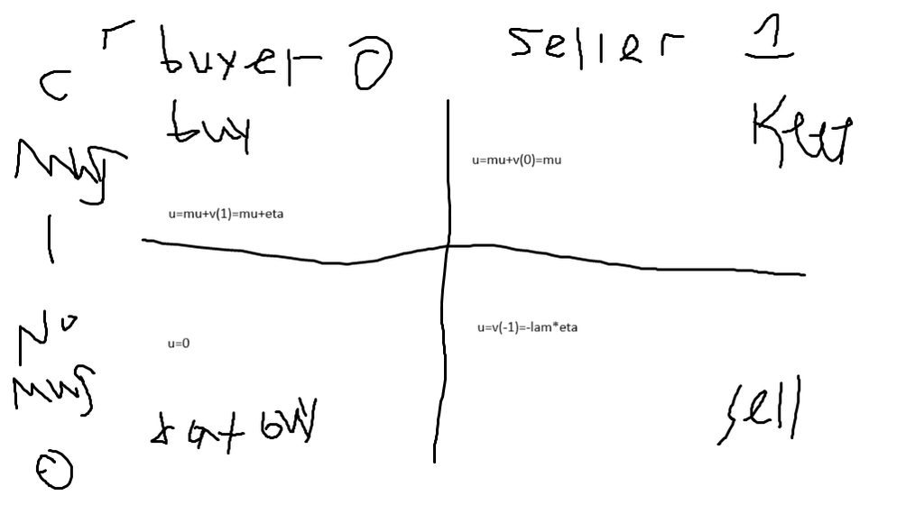

(a) That's a lot of variables

- (i) Reservation values are the point where money utility alone overcomes mug utility and money utility. Cash alone is c=0, cash and mug is c=1. Since $u_m(m)=m$, we can neglect their initial wealth and say that their utiltiy for the mug minus their utiltiy for not having their mug is equal to their reservation value
  - Buyers: $r = 0$ $$ u(1,0)-u(0,0)= \mu + v(1) - v(0) = \mu + \eta_\text{mug}$$
  - Sellers: $r = 1$ $$ u(1,1)-u(0,1)= \mu - v(-1) = \mu + \lambda_\text{mug} \eta_\text{mug} $$
  - Choosers: $r = 0$ $$ u(1,0)-u(0,0) \text{ This is the same as Buyers}$$
- (ii) With the special case, this yields a value for buyers and choosers of 3.5 and sellers 5.5. It appears sellers won't sell to buyers or choosers, since they value their mugs higher than people without them (they're less willing to get rid of them due to $\lambda_\text{mug}$)

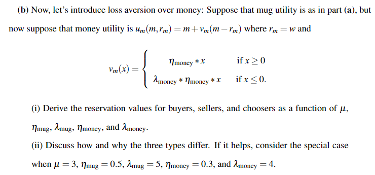

(b) Even more variables yay. Now $r_m=w$ means our initial value of $15,000 is important.

- (i) Sellers will have a net positive wealth if they sell the mug, while buyers have a negative $v_m$ if they choose to buy the mug. Choosers will choose a positive cash value in exchange for the mug, yielding a positive wealth. Total utility is constant at the indifference point. Unlabeled variables relate to the mug.
  - Buyer: Buy mug $U_\text{total} = u_m(m_0,r_m)+u(1,0)$, don't buy mug $U_\text{total}=u_m(r_m,r_m) + u(0,0)$ $$ m_0 + v_m(m_0-15000) + \mu + \eta = 15000 + v(0,0)\\ m_0 + (m_0-15000)*\lambda_\text{money}\eta_\text{money} =15000-\mu-\eta \\ m_0(1+\lambda_\text{money}\eta_\text{money}) =15000-\mu-\eta+15000\lambda_\text{money}\eta_\text{money} \\ m_0 = \frac{15000-\mu-\eta+15000\lambda_\text{money}\eta_\text{money}}{(1+\lambda_\text{money}\eta_\text{money})} $$
  - Seller: $$ 15000+\mu = m_0+v_m(m_0-15000)-\lambda\eta \\ 15000+\mu = m_0+(m_0-15000)*\eta_\text{money}-\lambda\eta \\ 15000+\mu+\lambda\eta+15000*\eta_\text{money} = m_0(1+\eta_\text{money}) \\ m_0 = \frac{15000+\mu+\lambda\eta+15000*\eta_\text{money}}{(1+\eta_\text{money})} $$
  - Chooser: $$ 15000+\mu = m_0 + v_m(m_0-15000) = m_0 + (m_0-15000)\eta_\text{money} \\ 15000+\mu+15000\eta_\text{money} = m_0(1+\eta_\text{money}) \\ m_0 = \frac{15000+\mu+15000\eta_\text{money}}{1+\eta_\text{money}} $$ Find the difference between m_0 and 15000 to find the mug indifference value
- (ii) Buyer price $1.59, Seller price $4.23, Chooser price $2.31. The reasoning is similar to part (a), only now choosers do not have the same issue with loosing money $\lambda_\text{money} $ as buyers, increasing their indifference value.

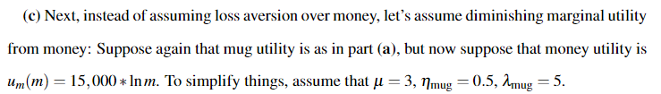

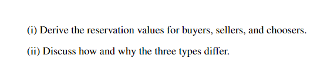

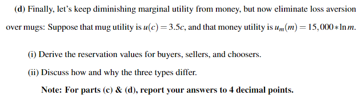

(d) Mug utility is simply 3.5 or 0.

- (i)
  - Buyer: $$ 15000\ln(m_0) + 3.5 = 15000\ln(15000)\\ m_0=e^{\ln(15000)-3.5/15000} \\ m_0=15000-3.4996 $$
  - Seller: $$ 15000\ln(15000)+3.5 = 15000\ln(m_0) \\ m_0=e^{\ln(15000)+3.5/15000} \\ m_0=15000+3.5004 $$
  - Chooser: $$ 15000\ln(15000)+3.5 = 15000\ln(m_0) \\ \text{same as seller} \\ m_0=15000+3.5004 $$
- (ii) They don't differ by much, but sale still doesn't occur between buyers and sellers who don't make rounding errors. Without any utility earned from buying or lost from selling a mug, there isn't much differentiating buyers, sellers, or choosers, and the minute reduction in buyer's indifference point is due to diminishing marginal utility.

# Question 10

Nah not tonight

Definitions I pulled up answering these:

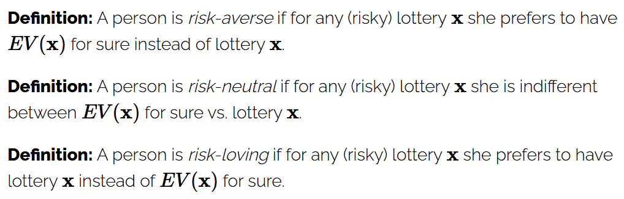

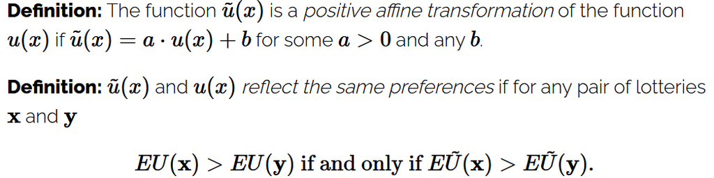

[figure not shown]

[figure not shown]

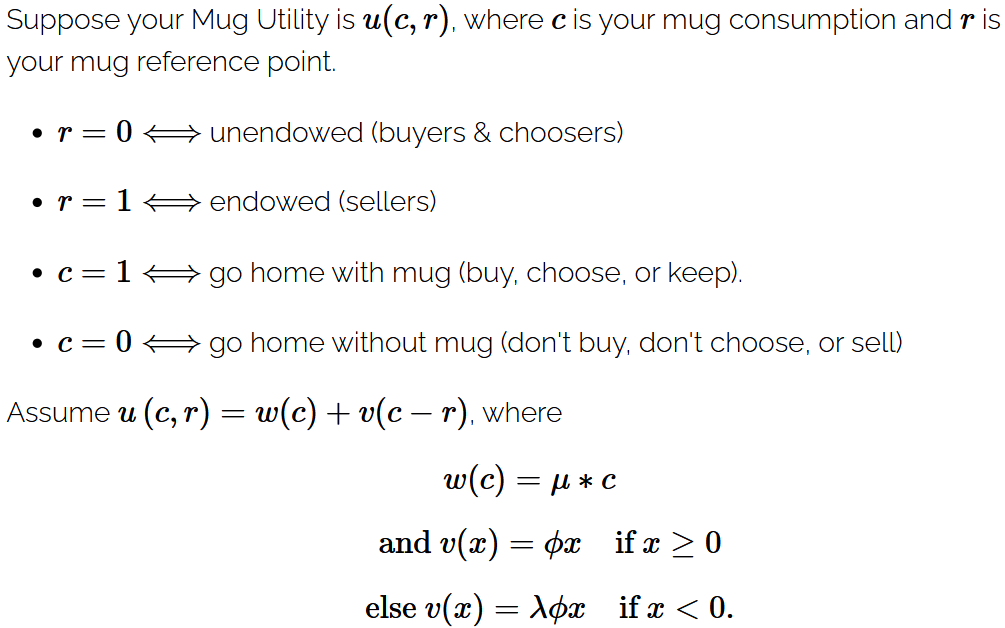